# **Projet Data Mining analyse + classification online retail dataset**

```python
# importations des bibliotheques
import pandas as pd
import seaborn as sns
import numpy as np
import matplotlib.pyplot as plt
```

```python
#Chargement des Donnees
df = pd.read_excel("C://Users//abenh//Downloads//online+retail+ii//online_retail_II.xlsx")
df.head()
```

|  | Invoice | StockCode | Description | Quantity | InvoiceDate | Price | Customer ID | Country |
| --- | --- | --- | --- | --- | --- | --- | --- | --- |
| 0 | 489434 | 85048 | 15CM CHRISTMAS GLASS BALL 20 LIGHTS | 12 | 2009-12-01 07:45:00 | 6.95 | 13085.0 | United Kingdom |
| 1 | 489434 | 79323P | PINK CHERRY LIGHTS | 12 | 2009-12-01 07:45:00 | 6.75 | 13085.0 | United Kingdom |
| 2 | 489434 | 79323W | WHITE CHERRY LIGHTS | 12 | 2009-12-01 07:45:00 | 6.75 | 13085.0 | United Kingdom |
| 3 | 489434 | 22041 | RECORD FRAME 7" SINGLE SIZE | 48 | 2009-12-01 07:45:00 | 2.10 | 13085.0 | United Kingdom |
| 4 | 489434 | 21232 | STRAWBERRY CERAMIC TRINKET BOX | 24 | 2009-12-01 07:45:00 | 1.25 | 13085.0 | United Kingdom |

Statistiques descreptives:

```python
df.describe()
```

|  | Quantity | InvoiceDate | Price | Customer ID |
| --- | --- | --- | --- | --- |
| count | 525461.000000 | 525461 | 525461.000000 | 417534.000000 |
| mean | 10.337667 | 2010-06-28 11:37:36.845017856 | 4.688834 | 15360.645478 |
| min | -9600.000000 | 2009-12-01 07:45:00 | -53594.360000 | 12346.000000 |
| 25% | 1.000000 | 2010-03-21 12:20:00 | 1.250000 | 13983.000000 |
| 50% | 3.000000 | 2010-07-06 09:51:00 | 2.100000 | 15311.000000 |
| 75% | 10.000000 | 2010-10-15 12:45:00 | 4.210000 | 16799.000000 |
| max | 19152.000000 | 2010-12-09 20:01:00 | 25111.090000 | 18287.000000 |
| std | 107.424110 | NaN | 146.126914 | 1680.811316 |

```python
df.info()
```

```
<class 'pandas.core.frame.DataFrame'>
RangeIndex: 525461 entries, 0 to 525460
Data columns (total 8 columns):
 #   Column       Non-Null Count   Dtype
---  ------       --------------   -----
 0   Invoice      525461 non-null  object
 1   StockCode    525461 non-null  object
 2   Description  522533 non-null  object
 3   Quantity     525461 non-null  int64
 4   InvoiceDate  525461 non-null  datetime64[ns]
 5   Price        525461 non-null  float64
 6   Customer ID  417534 non-null  float64
 7   Country      525461 non-null  object
dtypes: datetime64[ns](1), float64(2), int64(1), object(4)
memory usage: 32.1+ MB
```

# **GRAPHIQUES BASIQUES POUR DECRIRE UNE VARIABLE**

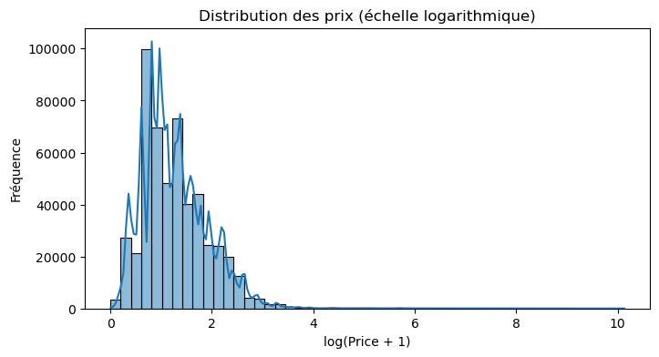

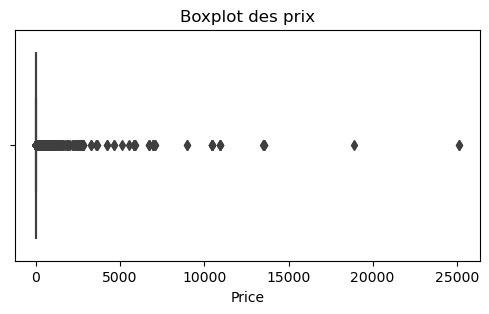

```python
# Supprimer les lignes avec un prix négatif ou nul
df = df[df['Price'] > 0]
#Appliquer la fonction log pour que les rectangles soient visibles apres le squewness de prix
df['log_price'] = np.log1p(df['Price'])  # log1p handles zero values safely

plt.figure(figsize=(8,4))
sns.histplot(df['log_price'], bins=50, kde=True)
plt.title("Distribution des prix (échelle logarithmique)")
plt.xlabel("log(Price + 1)")
plt.ylabel("Fréquence")
plt.show()
# Boxplot des prix
plt.figure(figsize=(6,3))
sns.boxplot(x=df['Price'])
plt.title("Boxplot des prix")
plt.show()
```

La majorité des produits ont un prix proche de zéro.

Très peu de produits dépassent les 20 unités monétaires.

Le graphique est très déséquilibré : une longue queue à droite (distribution asymétrique à droite).

Cela ressemble à une distribution en loi de puissance (beaucoup de petits prix, quelques prix très élevés). =>Conclusion : La variable Price est fortement asymétrique : la plupart des articles coûtent très peu, tandis que quelques produits très chers influencent la distribution. Cette asymétrie doit être prise en compte lors de l’analyse (ex : normalisation, transformation log).

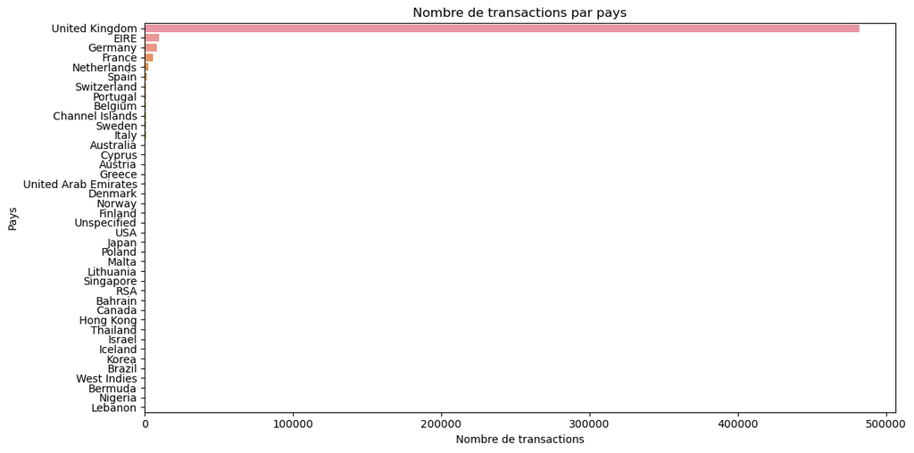

```python
plt.figure(figsize=(12,6))
sns.countplot(y='Country', data=df, order=df['Country'].value_counts().index)
plt.title("Nombre de transactions par pays")
plt.xlabel("Nombre de transactions")
plt.ylabel("Pays")
plt.tight_layout()
plt.show()
```

on constate que la majorite des pays sont de UK c'est normal car ceci est une dataset d'une entreprise sur l'UK

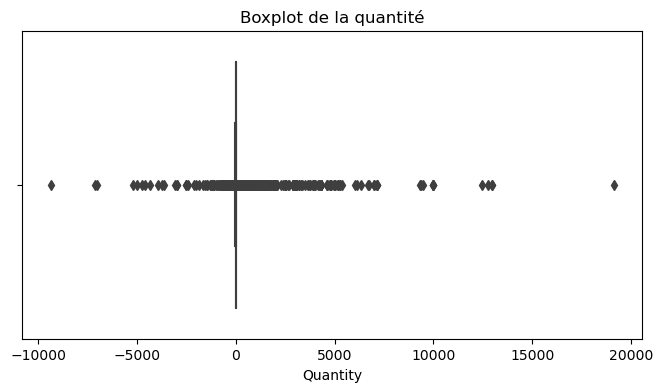

```
Nombre d'outliers dans la quantité avant: 56071
```

```python
# Boxplot Quantity
plt.figure(figsize=(8,4))
sns.boxplot(x=df['Quantity'])
plt.title("Boxplot de la quantité")
plt.show()

# Find outliers using IQR
Q1 = df['Quantity'].quantile(0.25)
Q3 = df['Quantity'].quantile(0.75)
IQR = Q3 - Q1
outliers = df[(df['Quantity'] < Q1 - 1.5 * IQR) | (df['Quantity'] > Q3 + 1.5 * IQR)]

print("Nombre d'outliers dans la quantité avant:", len(outliers))
# Function to remove outliers using IQR
def remove_outliers_iqr(df, column):
    Q1 = df[column].quantile(0.25)
    Q3 = df[column].quantile(0.75)
    IQR = Q3 - Q1
    lower_bound = Q1 - 1.5 * IQR
    upper_bound = Q3 + 1.5 * IQR
    return df[(df[column] >= lower_bound) & (df[column] <= upper_bound)]

# Remove outliers from both columns
df_filtered = remove_outliers_iqr(df, 'Quantity')
df_filtered = remove_outliers_iqr(df_filtered, 'Price')
```

De nombreuses transactions comportent des valeurs négatives ou extrêmement élevées dans la colonne Quantity, ce qui pourrait indiquer des retours ou des erreurs de saisie. Ces valeurs doivent être nettoyées ou analysées séparémen

```python
#nmbre des produits uniques
print("Nombre de produits uniques :", df['Description'].nunique())
```

```
Nombre de produits uniques : 4549
```

Il y a des milliers de produits différents — cela peut justifier une classification (ou regroupement) des produits selon leur description, ou un clustering (K-means par exemple) basé sur leur prix/quantité.

# **RELATION ENTRE VARIABLES QUANTITATIVES**

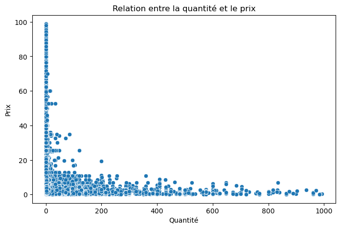

```python
# Filtrer les valeurs aberrantes pour une meilleure visibilité
df_filtered = df[(df['Price'] > 0) & (df['Price'] < 100) & (df['Quantity'] < 1000) & (df['Quantity'] > 0)]

plt.figure(figsize=(8,5))
sns.scatterplot(data=df_filtered, x='Quantity', y='Price')
plt.title("Relation entre la quantité et le prix")
plt.xlabel("Quantité")
plt.ylabel("Prix")
#Donner un limite pour que les valeurs ne seront pas inisibles
plt.xlim=(0,500)
plt.show()
```

La plupart des prix sont bas

La majorité des prix sont regroupés en dessous de 10 unités, surtout lorsque la quantité augmente.

Relation inverse (non linéaire)

Cela suggère que les achats en gros peuvent être assortis de remises ou que des articles moins chers sont achetés en plus grande quantité.

Prix élevé pour faible quantité

Certains points affichent des prix très élevés (jusqu'à 80 à 90 unités) pour de petites quantités, ce qui pourrait indiquer des articles de luxe ou de grande valeur achetés en petit nombre.

Données de rechange en grande quantité et à prix élevé

Il n’y a pratiquement pas de transactions à prix élevé et en grande quantité. Cela est logique : les articles très chers ne sont généralement pas achetés en gros.

=>Aucune relation claire linéaire entre Price et Quantity. Les produits bon marché peuvent être vendus en grande ou faible quantité. Cela suggère qu’un clustering pourrait être utile pour regrouper les comportements.

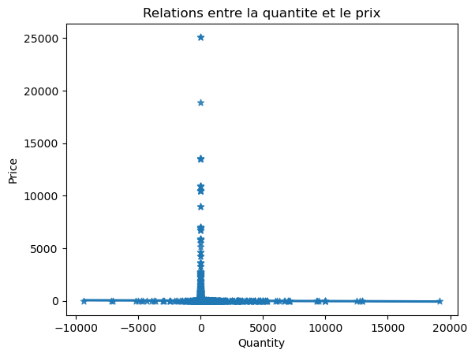

```python
sns.regplot(
    x="Quantity",
    y="Price",
    fit_reg=True,
    marker="*",
    data=df).set_title("Relations entre la quantite et le prix");
```

```python
from scipy import stats
#corelation entre quantite et prix
stats.pearsonr(df['Quantity'], df['Price'])
```

```
PearsonRResult(statistic=-0.0039934835191884665, pvalue=0.003918537528208115)
```

il y'a une faible correlation entre le Prix et la quantite (r est proche de 0)

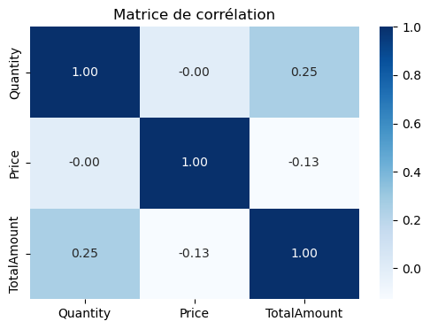

```python
df['TotalAmount'] = df['Quantity'] * df['Price']
# Calcul de la matrice de corrélation
correlation_matrix = df[['Quantity', 'Price', 'TotalAmount']].corr()

# Affichage de la heatmap
plt.figure(figsize=(6,4))
sns.heatmap(correlation_matrix, annot=True, cmap='Blues', fmt=".2f")
plt.title("Matrice de corrélation")
plt.show()
```

Mais cette corrélation est faible, donc pas très forte ni systématique.

Cela peut s’expliquer par des achats de grosses quantités à petits prix, ce qui réduit TotalAmount.

1. Price & Quantity → Corrélation nulle (0.00) Cela confirme qu’il n’existe aucune relation linéaire entre le prix d’un article et la quantité achetée.

Ce comportement est typique dans des données commerciales : les clients achètent indépendamment du prix unitaire (pas de stratégie volume-prix claire).

Mais globalement, aucune des deux variables n’a une forte influence isolée sur le montant total (car corrélation faible).

Cela suggère une grande diversité des comportements clients : certains achètent peu à prix élevé, d'autres beaucoup à bas prix.

# **RELATION ENTRE VARIABLES QUALITATIVES : TABLEAU DE CONTINGENCE**

```python
# remplacement des valuers nulle par moyenne et Création du tableau de contingence
contingency_table = pd.crosstab(df['Country'], df['StockCode'])

# Affichage du tableau
print(contingency_table)
```

```
StockCode             10002  10080  10109  10120  10125  10133  10134  10135  \
Country
Australia                 2      0      0      0      0      0      0      0
Austria                   0      0      0      0      0      0      0      0
Bahrain                   0      0      0      0      0      0      0      0
Belgium                   0      0      0      0      0      0      0      0
Bermuda                   0      0      0      0      0      0      0      0
Brazil                    0      0      0      0      0      0      0      0
Canada                    0      0      0      0      0      0      0      0
Channel Islands           0      0      0      0      0      0      0      0
Cyprus                    0      0      0      0      0      1      1      0
Denmark                   3      0      0      0      0      0      0      0
EIRE                      4      0      0      0      2      3      2      2
Finland                   0      0      0      0      0      0      0      0
France                   25      0      0      2      0      0      0      0
Germany                   6      0      0      0      2      0      0      2
Greece                    0      0      0      0      0      0      0      0
Hong Kong                 0      0      0      0      0      0      0      0
Iceland                   0      0      0      0      0      0      0      0
Israel                    0      0      0      0      0      0      0      0
Italy                     3      0      0      0      0      1      1      1
Japan                     1      0      0      0      0      0      0      0
Korea                     0      0      0      0      0      0      0      0
Lebanon                   0      0      0      0      0      0      0      0
Lithuania                 0      0      0      0      0      0      0      0
Malta                     0      0      0      0      0      0      0      0
Netherlands               1      0      0      0      0      0      0      0
Nigeria                   0      0      0      0      0      0      0      0
Norway                    0      0      0      0      1      0      0      0
Poland                    0      0      0      0      0      0      0      0
Portugal                  0      0      0      0      0      0      0      0
RSA                       0      0      0      0      0      0      0      0
Singapore                 0      0      0      0      0      0      0      0
Spain                     3      0      0      0      0      0      0      0
Sweden                    1      0      0      0      0      0      0      0
Switzerland               2      0      0      0      0      0      0      0
Thailand                  0      0      0      0      0      0      0      0
USA                       0      0      0      0      0      0      0      0
United Arab Emirates      0      0      0      0      0      0      0      0
United Kingdom          276      6      1     46     82     97     53    156
```

[output cut: 118 more lines]

```
Poland                           0             0  0
Portugal                         0             0  0
RSA                              0             0  0
Singapore                        0             0  0
Spain                            0             0  0
Sweden                           0             0  0
Switzerland                      0             0  0
Thailand                         0             0  0
USA                              0             0  0
United Arab Emirates             0             0  0
United Kingdom                   1             2  4
Unspecified                      0             0  0
West Indies                      0             0  0

[40 rows x 4265 columns]
```

```python
#table de contingence entre  Country et Invoice
pd.crosstab(df['Country'], df['Invoice'].nunique())
```

| col_0 Country | 25543 |
| --- | --- |
| Australia | 654 |
| Austria | 537 |
| Bahrain | 107 |
| Belgium | 1053 |
| Bermuda | 34 |
| Brazil | 62 |
| Canada | 77 |
| Channel Islands | 906 |
| Cyprus | 554 |
| Denmark | 428 |
| EIRE | 9669 |
| Finland | 354 |
| France | 5772 |
| Germany | 8122 |
| Greece | 517 |
| Hong Kong | 76 |
| Iceland | 71 |
| Israel | 74 |
| Italy | 731 |
| Japan | 224 |
| Korea | 63 |
| Lebanon | 13 |
| Lithuania | 154 |
| Malta | 172 |
| Netherlands | 2768 |
| Nigeria | 32 |
| Norway | 369 |
| Poland | 194 |
| Portugal | 1101 |
| RSA | 111 |
| Singapore | 117 |
| Spain | 1278 |
| Sweden | 902 |
| Switzerland | 1187 |
| Thailand | 76 |
| USA | 244 |
| United Arab Emirates | 432 |
| United Kingdom | 482172 |
| Unspecified | 310 |
| West Indies | 54 |

```python
#Top Products by Quantity Sold
df.groupby('StockCode')['Quantity'].sum().sort_values(ascending=False).head(10)
```

```
StockCode
21212     59411
85123A    57427
84077     54587
85099B    49773
17003     47637
84879     44917
84991     36326
22197     32639
21977     31822
21232     26562
Name: Quantity, dtype: int64
```

```python
df[df["StockCode"]==21212]
```

|  | Invoice | StockCode | Description | Quantity | InvoiceDate | Price | Customer ID | Country | log_price | TotalAmount |
| --- | --- | --- | --- | --- | --- | --- | --- | --- | --- | --- |
| 246 | 489461 | 21212 | PACK OF 72 RETRO SPOT CAKE CASES | 24 | 2009-12-01 10:49:00 | 0.55 | 17865.0 | United Kingdom | 0.438255 | 13.20 |
| 701 | 489532 | 21212 | PACK OF 72 RETRO SPOT CAKE CASES | 24 | 2009-12-01 11:58:00 | 0.55 | 13394.0 | United Kingdom | 0.438255 | 13.20 |
| 1050 | 489546 | 21212 | PACK OF 72 RETRO SPOT CAKE CASES | 24 | 2009-12-01 12:30:00 | 0.55 | 14156.0 | EIRE | 0.438255 | 13.20 |
| 1180 | 489556 | 21212 | PACK OF 72 RETRO SPOT CAKE CASES | 24 | 2009-12-01 12:47:00 | 0.55 | 15719.0 | United Kingdom | 0.438255 | 13.20 |
| 1233 | 489557 | 21212 | PACK OF 72 RETRO SPOT CAKE CASES | 24 | 2009-12-01 12:52:00 | 0.55 | 12490.0 | France | 0.438255 | 13.20 |
| ... | ... | ... | ... | ... | ... | ... | ... | ... | ... | ... |
| 523224 | 538035 | 21212 | PACK OF 72 RETROSPOT CAKE CASES | 2 | 2010-12-09 13:03:00 | 0.55 | 16065.0 | United Kingdom | 0.438255 | 1.10 |
| 523701 | 538071 | 21212 | PACK OF 72 RETROSPOT CAKE CASES | 12 | 2010-12-09 14:09:00 | 1.28 | NaN | United Kingdom | 0.824175 | 15.36 |
| 524293 | 538076 | 21212 | PACK OF 72 RETROSPOT CAKE CASES | 3 | 2010-12-09 14:15:00 | 0.55 | 15311.0 | United Kingdom | 0.438255 | 1.65 |
| 524366 | 538078 | 21212 | PACK OF 72 RETROSPOT CAKE CASES | 24 | 2010-12-09 14:25:00 | 0.55 | 16255.0 | United Kingdom | 0.438255 | 13.20 |
| 525338 | 538168 | 21212 | PACK OF 72 RETROSPOT CAKE CASES | 5 | 2010-12-09 19:23:00 | 0.55 | 14702.0 | United Kingdom | 0.438255 | 2.75 |

1933 rows × 10 columns

Le produit de stock code 21212 est le plus populaire "PACK OF 72 RETRO SPOT CAKE CASES"

```python
df.groupby('StockCode')['Price'].mean().sort_values(ascending=False).head(10)
#prix moyenne des Produits
```

```
StockCode
AMAZONFEE       8859.906667
M                632.441331
BANK CHARGES     447.936462
22655            295.000000
22656            279.717391
ADJUST2          243.683333
ADJUST           163.591343
22827            160.000000
DOT              159.037473
22828            151.666667
Name: Price, dtype: float64
```

```python
df['TotalPrice'] = df['Quantity'] * df['Price']
df.groupby('Customer ID')['TotalPrice'].sum().sort_values(ascending=False).head(10)
#les clients qui depensent le plus
```

```
Customer ID
18102.0    341776.73
14646.0    243853.05
14156.0    183180.55
14911.0    137675.91
13694.0    128172.42
17511.0     83760.60
15061.0     82162.74
16684.0     75610.17
13089.0     55828.31
16754.0     54558.18
Name: TotalPrice, dtype: float64
```

```python
import calendar

# Step 1: Extract month number and hour from InvoiceDate
df['Month'] = df['InvoiceDate'].dt.month
df['Hour'] = df['InvoiceDate'].dt.hour

# Step 2: Convert numeric month to full month name
df['MonthName'] = df['Month'].apply(lambda x: calendar.month_name[x])

# Step 3: Crosstab of product Description by MonthName
ct = pd.crosstab(df['Description'], df['MonthName'])

# Step 4: Sort the columns in calendar order
month_order = list(calendar.month_name)[1:]  # January to December
ct = ct.reindex(columns=month_order)

# Step 5: Add totals
ct['Total'] = ct.sum(axis=1)
ct.loc['Total'] = ct.sum()

# Show crosstab
print(ct)

# Step 6: Get most popular product(s) per month
most_popular_per_month = ct.drop(index='Total').idxmax()

print("\nMost popular product(s) per month:")
print(most_popular_per_month)
```

```
MonthName                            January  February  March  April    May  \
Description
  DOORMAT UNION JACK GUNS AND ROSES       56         3      3      0      0
 3 STRIPEY MICE FELTCRAFT                 18        38     13      1      1
 4 PURPLE FLOCK DINNER CANDLES             0         0      0      0      0
 ANIMAL STICKERS                           4         0      2      0      0
 BLACK PIRATE TREASURE CHEST               3         0      0      0      0
...                                      ...       ...    ...    ...    ...
ZINC METAL HEART DECORATION               87        53     76     56     69
ZINC POLICE BOX LANTERN                    2         0      1      0      0
ZINC TOP  2 DOOR WOODEN SHELF             11         1      5      5      1
ZINC WILLIE WINKIE  CANDLE STICK          37        17     33     12     23
Total                                  31324     28857  41208  33894  34778

MonthName                             June   July  August  September  October  \
Description
  DOORMAT UNION JACK GUNS AND ROSES      0      0       0          0        0
 3 STRIPEY MICE FELTCRAFT                1      1       0          0        0
 4 PURPLE FLOCK DINNER CANDLES           0      0       2          3        4
 ANIMAL STICKERS                         0      0       0          0        0
 BLACK PIRATE TREASURE CHEST             0      0       0          0        0
...                                    ...    ...     ...        ...      ...
ZINC METAL HEART DECORATION             57     66      72         66      104
ZINC POLICE BOX LANTERN                  0      0       0          0        0
ZINC TOP  2 DOOR WOODEN SHELF            0      2       2          2        2
ZINC WILLIE WINKIE  CANDLE STICK        16     18      35         29       49
Total                                39693  33237   33046      41921    58838

MonthName                            November  December   Total
Description
  DOORMAT UNION JACK GUNS AND ROSES         0         0      62
 3 STRIPEY MICE FELTCRAFT                   0        61     134
 4 PURPLE FLOCK DINNER CANDLES             10         2      21
 ANIMAL STICKERS                            0         6      12
 BLACK PIRATE TREASURE CHEST                0        20      23
...                                       ...       ...     ...
ZINC METAL HEART DECORATION               129       112     947
ZINC POLICE BOX LANTERN                     0         3       6
ZINC TOP  2 DOOR WOODEN SHELF               5        17      53
ZINC WILLIE WINKIE  CANDLE STICK           58        61     388
Total                                   77658     67317  521771

[4550 rows x 13 columns]

Most popular product(s) per month:
MonthName
January      WHITE HANGING HEART T-LIGHT HOLDER
February     WHITE HANGING HEART T-LIGHT HOLDER
March        WHITE HANGING HEART T-LIGHT HOLDER
April        WHITE HANGING HEART T-LIGHT HOLDER
May          WHITE HANGING HEART T-LIGHT HOLDER
June         WHITE HANGING HEART T-LIGHT HOLDER
July         WHITE HANGING HEART T-LIGHT HOLDER
August       WHITE HANGING HEART T-LIGHT HOLDER
September              REGENCY CAKESTAND 3 TIER
October      WHITE HANGING HEART T-LIGHT HOLDER
November     WHITE HANGING HEART T-LIGHT HOLDER
December     WHITE HANGING HEART T-LIGHT HOLDER
Total        WHITE HANGING HEART T-LIGHT HOLDER
dtype: object
```

pendant les pluspart des mois le plus popular item est WHOTE HANDING HEAR T-LIGHT HOLDER mais pendant deptember REGNEY CAKESTAND 3 TIER est le plus popluar item

```python
df['Month'] = df['InvoiceDate'].dt.month

pd.crosstab(df['Description'], df['Hour'], margins=True)
#tableau de contingence entre Hour et Description pour etudier la relation a quelle heure chaque item est la plus populaire
```

| Hour Description | 7 | 8 | 9 | 10 | 11 | 12 | 13 | 14 | 15 | 16 | 17 | 18 | 19 | 20 | 21 | All |
| --- | --- | --- | --- | --- | --- | --- | --- | --- | --- | --- | --- | --- | --- | --- | --- | --- |
| DOORMAT UNION JACK GUNS AND ROSES | 0 | 0 | 2 | 4 | 8 | 12 | 8 | 12 | 5 | 3 | 7 | 1 | 0 | 0 | 0 | 62 |
| 3 STRIPEY MICE FELTCRAFT | 0 | 0 | 5 | 14 | 15 | 19 | 12 | 20 | 19 | 11 | 10 | 6 | 1 | 2 | 0 | 134 |
| 4 PURPLE FLOCK DINNER CANDLES | 0 | 0 | 0 | 2 | 4 | 7 | 2 | 1 | 3 | 2 | 0 | 0 | 0 | 0 | 0 | 21 |
| ANIMAL STICKERS | 0 | 1 | 1 | 1 | 2 | 2 | 0 | 1 | 2 | 1 | 0 | 0 | 1 | 0 | 0 | 12 |
| BLACK PIRATE TREASURE CHEST | 0 | 0 | 2 | 0 | 3 | 4 | 3 | 4 | 3 | 1 | 3 | 0 | 0 | 0 | 0 | 23 |
| ... | ... | ... | ... | ... | ... | ... | ... | ... | ... | ... | ... | ... | ... | ... | ... | ... |
| ZINC METAL HEART DECORATION | 1 | 8 | 58 | 83 | 113 | 170 | 133 | 151 | 96 | 55 | 46 | 17 | 15 | 1 | 0 | 947 |
| ZINC POLICE BOX LANTERN | 0 | 0 | 0 | 0 | 2 | 0 | 0 | 3 | 1 | 0 | 0 | 0 | 0 | 0 | 0 | 6 |
| ZINC TOP 2 DOOR WOODEN SHELF | 0 | 0 | 3 | 7 | 8 | 14 | 5 | 4 | 5 | 2 | 3 | 0 | 2 | 0 | 0 | 53 |
| ZINC WILLIE WINKIE CANDLE STICK | 1 | 8 | 39 | 29 | 31 | 45 | 44 | 66 | 55 | 33 | 22 | 12 | 3 | 0 | 0 | 388 |
| All | 744 | 7073 | 33797 | 43823 | 63626 | 80698 | 77720 | 73649 | 57154 | 39113 | 28720 | 8956 | 5363 | 1334 | 1 | 521771 |

4550 rows × 16 columns

```python
#le prix par rapport au pays


# Step 1: Effacer United Kingdom car elle est la plupart de dataset
df_filtered = df[df['Country'] != 'United Kingdom']

# Step 2: Categorize Price into PriceRange (low, medium, high, etc.)
df_filtered['PriceRange'] = pd.cut(df_filtered['Price'], bins=[0, 10, 50, 100, 500, 1000], labels=['Low', 'Medium', 'High', 'Very High', 'Luxury'])

# Step 3: Create contingency table, normalize by 'index' (normalize by rows, i.e., by country)
ct = pd.crosstab(df_filtered['PriceRange'], df_filtered['Country'], normalize='index')

# Step 4: Convert to percentage format
ct_percentage = ct * 100

# Step 5: Check if normalization is correct (each row should sum to 100%)
print("Row sums after normalization:")
print(ct_percentage.sum(axis=1))  # Should print 100% for each row

# Step 6: Display the contingency table with percentages
print("Contingency Table with Percentages:")
print(ct_percentage)
```

```
Row sums after normalization:
PriceRange
Low          100.0
Medium       100.0
High         100.0
Very High    100.0
Luxury       100.0
dtype: float64
Contingency Table with Percentages:
Country     Australia   Austria   Bahrain   Belgium   Bermuda   Brazil  \
PriceRange
Low          1.696681  1.360017  0.277882  2.591781  0.088174  0.16566
Medium       0.695825  1.242545  0.149105  3.876740  0.049702  0.00000
High         3.448276  0.000000  0.000000  0.000000  0.000000  0.00000
Very High    3.076923  4.615385  0.000000  4.615385  0.000000  0.00000
Luxury       5.128205  0.000000  0.000000  0.000000  0.000000  0.00000

Country       Canada  Channel Islands    Cyprus   Denmark  ...       RSA  \
PriceRange                                                 ...
Low         0.205739         2.182974  1.397424  1.103511  ...  0.288569
Medium      0.000000         4.274354  1.441352  0.745527  ...  0.049702
High        0.000000         3.448276  6.896552  0.000000  ...  0.000000
Very High   0.000000         1.538462  0.000000  0.000000  ...  0.000000
Luxury      0.000000         2.564103  0.000000  0.000000  ...  0.000000

Country     Singapore      Spain     Sweden  Switzerland  Thailand       USA  \
PriceRange
Low          0.299257   3.168920   2.281836     3.043339  0.192380  0.622562
Medium       0.248509   4.075547   2.037773     2.335984  0.198807  0.397614
High         0.000000   3.448276   6.896552     0.000000  0.000000  0.000000
Very High    0.000000  10.769231   1.538462     0.000000  0.000000  4.615385
Luxury       0.000000   5.128205  10.256410     2.564103  0.000000  0.000000

Country     United Arab Emirates  Unspecified  West Indies
PriceRange
Low                     1.108855     0.782878     0.144285
Medium                  0.646123     0.795229     0.000000
High                    3.448276     0.000000     0.000000
Very High               1.538462     0.000000     0.000000
Luxury                  5.128205     0.000000     0.000000

[5 rows x 39 columns]
```

Des pays comme l'Emirates sont Achetent plus des produits chers par rapport aux autres pays et d'autres pays mois riches comme brazil achetent seulement les produits Non chers

# **Pretraitement des donnees**

```python
# Check for missing values
missing_data = df.isnull().sum()

# Handle missing values for categorical and non-categorical columns
df['Customer ID'].fillna('Unknown', inplace=True)



df['Quantity'].fillna(0, inplace=True)
df['Price'].fillna(df['Price'].median(), inplace=True)
df['Description'].fillna('Unknown', inplace=True)

missing_data_after = df.isnull().sum()
print("Missing Data After Handling:")
print(missing_data_after)
```

```
Missing Data After Handling:
Invoice        0
StockCode      0
Description    0
Quantity       0
InvoiceDate    0
Price          0
Customer ID    0
Country        0
log_price      0
TotalAmount    0
TotalPrice     0
Month          0
Hour           0
MonthName      0
dtype: int64
```

=>Les donnes nulls ont disparés

```python
#Effacer les lignes dupliques
df.drop_duplicates(inplace=True)
# Convertir les types de donnees
df['InvoiceDate'] = pd.to_datetime(df['InvoiceDate'])
df['Quantity'] = df['Quantity'].astype(int)
df['Price'] = df['Price'].astype(float)
```

```python
#Normaliser et scaling les colonnes numerics  comme Price et Quantity
from sklearn.preprocessing import StandardScaler

# Standardize the Price and Quantity columns
scaler = StandardScaler()
df[['Price', 'Quantity']] = scaler.fit_transform(df[['Price', 'Quantity']])
```

```python
from scipy.stats import zscore

# Calculate z-scores for numerical columns
z_scores = np.abs(zscore(df[['Price', 'Quantity']]))
df = df[(z_scores < 3).all(axis=1)]  # Remove rows with z-scores > 3
#effacer les outliers
```

```python
df
```

|  | Invoice | StockCode | Description | Quantity | InvoiceDate | Price | Customer ID | Country | log_price | TotalAmount | TotalPrice | Month | Hour | MonthName |
| --- | --- | --- | --- | --- | --- | --- | --- | --- | --- | --- | --- | --- | --- | --- |
| 0 | 489434 | 85048 | 15CM CHRISTMAS GLASS BALL 20 LIGHTS | 0.012306 | 2009-12-01 07:45:00 | 0.019850 | 13085.0 | United Kingdom | 2.073172 | 83.40 | 83.40 | 12 | 7 | December |
| 1 | 489434 | 79323P | PINK CHERRY LIGHTS | 0.012306 | 2009-12-01 07:45:00 | 0.017798 | 13085.0 | United Kingdom | 2.047693 | 81.00 | 81.00 | 12 | 7 | December |
| 2 | 489434 | 79323W | WHITE CHERRY LIGHTS | 0.012306 | 2009-12-01 07:45:00 | 0.017798 | 13085.0 | United Kingdom | 2.047693 | 81.00 | 81.00 | 12 | 7 | December |
| 3 | 489434 | 22041 | RECORD FRAME 7" SINGLE SIZE | 0.406107 | 2009-12-01 07:45:00 | -0.029906 | 13085.0 | United Kingdom | 1.131402 | 100.80 | 100.80 | 12 | 7 | December |
| 4 | 489434 | 21232 | STRAWBERRY CERAMIC TRINKET BOX | 0.143573 | 2009-12-01 07:45:00 | -0.038627 | 13085.0 | United Kingdom | 0.810930 | 30.00 | 30.00 | 12 | 7 | December |
| ... | ... | ... | ... | ... | ... | ... | ... | ... | ... | ... | ... | ... | ... | ... |
| 525456 | 538171 | 22271 | FELTCRAFT DOLL ROSIE | -0.097083 | 2010-12-09 20:01:00 | -0.021186 | 17530.0 | United Kingdom | 1.373716 | 5.90 | 5.90 | 12 | 20 | December |
| 525457 | 538171 | 22750 | FELTCRAFT PRINCESS LOLA DOLL | -0.108022 | 2010-12-09 20:01:00 | -0.012979 | 17530.0 | United Kingdom | 1.558145 | 3.75 | 3.75 | 12 | 20 | December |
| 525458 | 538171 | 22751 | FELTCRAFT PRINCESS OLIVIA DOLL | -0.108022 | 2010-12-09 20:01:00 | -0.012979 | 17530.0 | United Kingdom | 1.558145 | 3.75 | 3.75 | 12 | 20 | December |
| 525459 | 538171 | 20970 | PINK FLORAL FELTCRAFT SHOULDER BAG | -0.097083 | 2010-12-09 20:01:00 | -0.012979 | 17530.0 | United Kingdom | 1.558145 | 7.50 | 7.50 | 12 | 20 | December |
| 525460 | 538171 | 21931 | JUMBO STORAGE BAG SUKI | -0.097083 | 2010-12-09 20:01:00 | -0.031445 | 17530.0 | United Kingdom | 1.081805 | 3.90 | 3.90 | 12 | 20 | December |

512667 rows × 14 columns

```python
print(df.columns)
```

```
Index(['Invoice', 'StockCode', 'Description', 'Quantity', 'InvoiceDate',
       'Price', 'Customer ID', 'Country', 'log_price', 'TotalAmount',
       'TotalPrice', 'Month', 'Hour', 'MonthName'],
      dtype='object')
```

# **Apprentissage Non Supervisee**

Clustering des Clients avec K-MEANS clustering

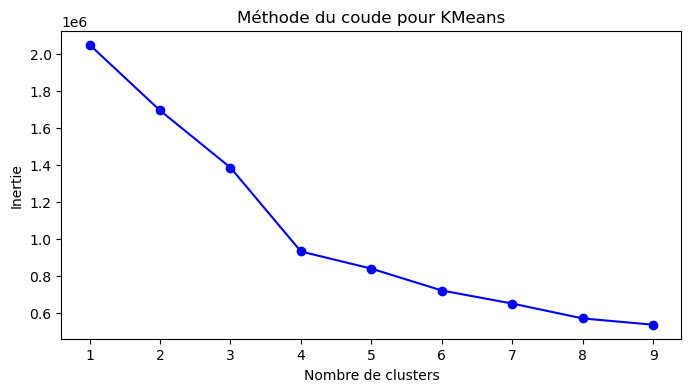

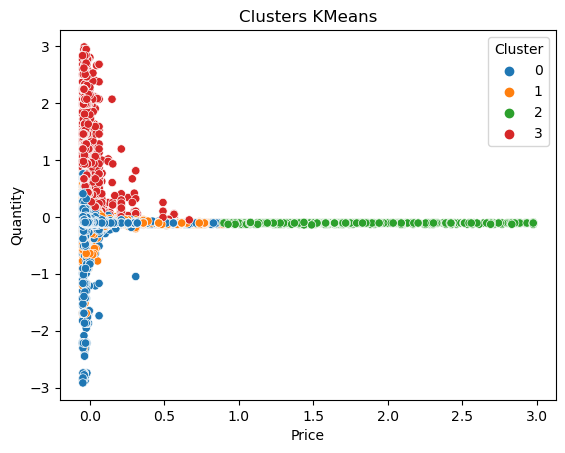

```python
from sklearn.cluster import KMeans
from sklearn.preprocessing import StandardScaler

# On garde uniquement les colonnes numériques pour le clustering
df_kmeans = df[['Quantity', 'Price', 'TotalAmount', 'Hour']]
df_kmeans = df_kmeans.dropna()

# Normalisation des données
scaler = StandardScaler()
X_scaled = scaler.fit_transform(df_kmeans)

# Déterminer le nombre optimal de clusters avec la méthode du coude
inertia = []
K = range(1, 10)
for k in K:
    kmeans = KMeans(n_clusters=k, random_state=42)
    kmeans.fit(X_scaled)
    inertia.append(kmeans.inertia_)

# Affichage de la courbe
plt.figure(figsize=(8, 4))
plt.plot(K, inertia, 'bo-')
plt.xlabel('Nombre de clusters')
plt.ylabel('Inertie')
plt.title('Méthode du coude pour KMeans')
plt.show()

# Supposons k=4 basé sur le coude
kmeans = KMeans(n_clusters=4, random_state=42)
df['Cluster'] = kmeans.fit_predict(X_scaled)

# Visualisation des clusters
sns.scatterplot(data=df, x='Price', y='Quantity', hue='Cluster', palette='tab10')
plt.title('Clusters KMeans')
plt.show()
```

Le graphique de la méthode du coude : Si la courbe forme un coude clair à k=4, cela indique que 4 clusters est un bon choix.

Le scatterplot Price vs Quantity avec les clusters :

Quels types de produits forment un groupe (ex : articles chers en faible quantité, ou produits peu chers en grande quantité).

Des groupes d’achats similaires (profil client ou type d’achat).

=>Le KMeans nous donne des segments clients ou produits, mais il ne explique pas les règles ou la nature exacte (pas d'étiquette connue).

Classification avec regles d'association

```python
from mlxtend.frequent_patterns import apriori, association_rules
from mlxtend.preprocessing import TransactionEncoder

# Préparer les transactions par facture
basket = df.groupby(['Invoice'])['Description'].apply(list)

# Transformer en format binaire
te = TransactionEncoder()
te_ary = te.fit(basket).transform(basket)
basket_df = pd.DataFrame(te_ary, columns=te.columns_)

# Appliquer Apriori
frequent_itemsets = apriori(basket_df, min_support=0.02, use_colnames=True)

# Générer les règles
rules = association_rules(frequent_itemsets, metric="lift", min_threshold=1)
rules = rules.sort_values(by='confidence', ascending=False)

# Affichage des règles les plus fortes
rules[['antecedents', 'consequents', 'support', 'confidence', 'lift']].head(10)
```

|  | antecedents | consequents | support | confidence | lift |
| --- | --- | --- | --- | --- | --- |
| 14 | (SWEETHEART CERAMIC TRINKET BOX) | (STRAWBERRY CERAMIC TRINKET BOX) | 0.032719 | 0.782775 | 11.094195 |
| 12 | (RED HANGING HEART T-LIGHT HOLDER) | (WHITE HANGING HEART T-LIGHT HOLDER) | 0.031079 | 0.716129 | 5.293892 |
| 20 | (WOODEN PICTURE FRAME WHITE FINISH) | (WOODEN FRAME ANTIQUE WHITE ) | 0.024359 | 0.635036 | 13.674890 |
| 7 | (LOVE BUILDING BLOCK WORD) | (HOME BUILDING BLOCK WORD) | 0.023479 | 0.532185 | 9.921817 |
| 4 | (HEART OF WICKER SMALL) | (HEART OF WICKER LARGE) | 0.021839 | 0.529070 | 12.090743 |
| 21 | (WOODEN FRAME ANTIQUE WHITE ) | (WOODEN PICTURE FRAME WHITE FINISH) | 0.024359 | 0.524548 | 13.674890 |
| 1 | (PACK OF 60 PINK PAISLEY CAKE CASES) | (60 TEATIME FAIRY CAKE CASES) | 0.023479 | 0.512216 | 9.599642 |
| 5 | (HEART OF WICKER LARGE) | (HEART OF WICKER SMALL) | 0.021839 | 0.499086 | 12.090743 |
| 15 | (STRAWBERRY CERAMIC TRINKET BOX) | (SWEETHEART CERAMIC TRINKET BOX) | 0.032719 | 0.463719 | 11.094195 |
| 18 | (WOODEN FRAME ANTIQUE WHITE ) | (WHITE HANGING HEART T-LIGHT HOLDER) | 0.021319 | 0.459087 | 3.393742 |

Siginidication des termes

| Terme | Signification |
| --- | --- |
| **Support** | Fréquence conjointe dans toutes les transactions |
| **Confiance** | Probabilité que le produit dans la conséquence soit acheté si celui de l'antécédent l’est |
| **Lift** | Mesure du lien entre les articles ; >1 signifie une association positive |

1. SWEETHEART CERAMIC TRINKET BOX → STRAWBERRY CERAMIC TRINKET BOX Support : 3.27% des paniers contiennent les deux.

Confiance : Quand quelqu’un achète SWEETHEART CERAMIC TRINKET BOX, il y a 78% de chances qu’il prenne aussi STRAWBERRY CERAMIC TRINKET BOX.

Lift : 11.09 → C’est 11 fois plus probable que par hasard. Très forte association !

1. RED HANGING HEART T-LIGHT HOLDER → WHITE HANGING HEART T-LIGHT HOLDER Confiance : 71.6% → Les clients qui achètent le rouge prennent très souvent aussi le blanc.

Lift : 5.29 → Forte corrélation.

1. WOODEN PICTURE FRAME WHITE FINISH → WOODEN FRAME ANTIQUE WHITE Confiance : 63.5%

Lift : 13.67 → Très forte synergie entre ces deux cadres photo.

1. LOVE BUILDING BLOCK WORD → HOME BUILDING BLOCK WORD Confiance : 53% → Produits de décoration très liés.

Lift : 9.92 → Très bonne association.

1. HEART OF WICKER SMALL → HEART OF WICKER LARGE Confiance : 52.9% → Les deux tailles sont souvent prises ensemble.

Lift : 12.09 → Forte complémentarité.

Conclusion générale : Les clients ont tendance à acheter des paires ou variantes de décoration similaires : objets cœur, cadres photo, boîtes en céramique.

Les valeurs de lift très élevées (5 à 13) indiquent une forte valeur commerciale pour des offres groupées ou promotions.

Tu peux exploiter ces résultats pour :

Faire du cross-selling (vendre ensemble).

Créer des bundles de produits.

Recommander dynamiquement des produits sur ton site.

# Classificatio Supervisée + tests

```python
from sklearn.model_selection import train_test_split
from sklearn.preprocessing import LabelEncoder, StandardScaler
from sklearn.linear_model import LogisticRegression
from sklearn.tree import DecisionTreeClassifier
from sklearn.ensemble import RandomForestClassifier
from sklearn.neighbors import KNeighborsClassifier
from sklearn.svm import SVC
from sklearn.metrics import accuracy_score, classification_report

# 2. Drop rows with negative or zero TotalAmount
df = df[df["TotalAmount"] > 0]

# 3. Create a new classification label: High vs Low Purchase (e.g., based on median)
df["HighSpender"] = (df["TotalAmount"] > df["TotalAmount"].median()).astype(int)

# 4. Encode categorical columns
le_country = LabelEncoder()
df["Country"] = le_country.fit_transform(df["Country"])

le_monthname = LabelEncoder()
df["MonthName"] = le_monthname.fit_transform(df["MonthName"])

# 5. Select features and target
features = ["Quantity", "Price", "log_price", "Country", "Month", "Hour", "MonthName"]
X = df[features]
y = df["HighSpender"]

# 6. Normalize the features
scaler = StandardScaler()
X_scaled = scaler.fit_transform(X)

# 7. Split into train and test sets
X_train, X_test, y_train, y_test = train_test_split(X_scaled, y, test_size=0.2, random_state=42)

# 8. Define classifiers
models = {
    "Logistic Regression": LogisticRegression(),
    "Decision Tree": DecisionTreeClassifier(),
    "Random Forest": RandomForestClassifier(),
    "K-Nearest Neighbors": KNeighborsClassifier(),
    "Support Vector Machine": SVC()
}

# 9. Train and evaluate models
for name, model in models.items():
    model.fit(X_train, y_train)
    y_pred = model.predict(X_test)
    print(f"\n{name}")
    print(f"Accuracy: {accuracy_score(y_test, y_pred):.4f}")
    print(classification_report(y_test, y_pred))
```

[output not shown]

```
Logistic Regression
Accuracy: 0.8725
              precision    recall  f1-score   support

           0       0.88      0.87      0.88     52535
           1       0.86      0.87      0.87     48024

    accuracy                           0.87    100559
   macro avg       0.87      0.87      0.87    100559
weighted avg       0.87      0.87      0.87    100559


Decision Tree
Accuracy: 1.0000
              precision    recall  f1-score   support

           0       1.00      1.00      1.00     52535
           1       1.00      1.00      1.00     48024

    accuracy                           1.00    100559
   macro avg       1.00      1.00      1.00    100559
weighted avg       1.00      1.00      1.00    100559


Random Forest
Accuracy: 0.9999
              precision    recall  f1-score   support

           0       1.00      1.00      1.00     52535
           1       1.00      1.00      1.00     48024

    accuracy                           1.00    100559
   macro avg       1.00      1.00      1.00    100559
weighted avg       1.00      1.00      1.00    100559


K-Nearest Neighbors
Accuracy: 0.9923
              precision    recall  f1-score   support

           0       0.99      0.99      0.99     52535
           1       0.99      0.99      0.99     48024

    accuracy                           0.99    100559
   macro avg       0.99      0.99      0.99    100559
weighted avg       0.99      0.99      0.99    100559
```

Interpretation :: | Modèle | Accuracy | Précision (0) | Rappel (0) | F1-score (0) | Précision (1) | Rappel (1) | F1-score (1) | | ------------------- | -------- | ------------- | ---------- | ------------ | ------------- | ---------- | ------------ | | Logistic Regression | 87.25 % | 0.88 | 0.87 | 0.88 | 0.86 | 0.87 | 0.87 | | Decision Tree | 100 % | 1.00 | 1.00 | 1.00 | 1.00 | 1.00 | 1.00 | | Random Forest | 99.99 % | 1.00 | 1.00 | 1.00 | 1.00 | 1.00 | 1.00 | | K-Nearest Neighbors | 99.23 % | 0.99 | 0.99 | 0.99 | 0.99 | 0.99 | 0.99 |

Modeles et interpretations

[output not shown]

Pourquoi utiliser chaque méthode ?

| Modèle | Pourquoi l’utiliser ? |
| --- | --- |
| **Logistic Regression** | ✔ Simple à interpréter ✔ Bon pour les cas linéaires ❌ Moins performant si données complexes |
| **Decision Tree** | ✔ Facile à visualiser ✔ Gère bien les variables catégoriques ❌ Sensible à l’overfitting |
| **Random Forest** | ✔ Excellent compromis biais/variance ✔ Moins d’overfitting ✔ Très robuste |
| **KNN** | ✔ Facile à comprendre ✔ Aucune hypothèse sur la distribution des données ❌ Lent à prédire, sensible aux valeurs extrêmes |